# Bioinformatics Project

wangjun

2023-09-22

# Data import and preliminary analysis

Import data set and check whether successful or not:

```r
# import data set
data <- read.csv("BRCA_RNASeqv2_top50.csv")

head(data)
```

|  | FIGF | LYVE1 | CD300LG | SCARA5 | PAMR1 | SDPR | MYOM1 | BTNL9 | KCNIP2 | SLC2A4 | PDE2A | LEP | ACVR1C | ABCA10 | AQP7 | GPR146 | ATP1A2 | FXYD1 | ARHGAP20 | NPR1 | ATOH8 | ABCA9 | ALDH1L1 | ADAMTS5 | RDH5 | GPAM | CA4 | KLHL29 | GPIHBP1 | … |
| --- | --- | --- | --- | --- | --- | --- | --- | --- | --- | --- | --- | --- | --- | --- | --- | --- | --- | --- | --- | --- | --- | --- | --- | --- | --- | --- | --- | --- | --- | --- |
| 1 | 544.1270 | 1360.952 | 602.8571 | 882.2222 | 2508.8889 | 1425.079 | 195.2381 | 717.7778 | 283.8095 | 68.8889 | 658.4127 | 987.3016 | 57.7778 | 164.1270 | 213.9683 | 262.5397 | 123.1746 | 302.5397 | 110.4762 | 807.9365 | 628.2540 | 396.1905 | 175.8730 | 1400.952 | 217.2603 | 1293.333 | 70.1587 | 505.3968 | 383.8095 | … |
| 2 | 846.2623 | 3508.792 | 1736.9064 | 2060.7428 | 1572.1674 | 4267.795 | 460.7428 | 2261.9652 | 2579.7837 | 400.1881 | 1729.0080 | 16210.6253 | 761.2600 | 244.0997 | 2694.4993 | 900.7992 | 1587.2120 | 782.3225 | 278.7024 | 3299.2948 | 1084.7203 | 1042.5952 | 1243.0654 | 1906.159 | 1804.9760 | 8317.818 | 754.1138 | 509.2619 | 1598.4955 | … |
| 3 | 741.3442 | 3423.116 | 4074.3381 | 6321.7923 | 675.1527 | 7398.676 | 2019.8574 | 4518.3299 | 8273.9308 | 1040.2240 | 2649.1853 | 37746.4358 | 3481.6701 | 244.3992 | 9354.8880 | 1536.1507 | 5110.9980 | 742.8717 | 759.1650 | 5919.5519 | 1054.4807 | 2514.7658 | 1870.6721 | 2656.823 | 3389.8371 | 42443.992 | 1114.5621 | 588.0855 | 1929.2261 | … |
| 4 | 905.1546 | 9641.237 | 2786.5979 | 10177.3196 | 1591.7526 | 3809.794 | 966.4948 | 2610.3093 | 5992.7835 | 958.7629 | 2597.9381 | 7954.1237 | 2986.0825 | 321.1340 | 3496.9072 | 1191.7526 | 4108.2474 | 588.1443 | 816.4948 | 4698.4536 | 1208.7629 | 2755.1546 | 3053.0928 | 8410.825 | 2129.8969 | 22096.392 | 428.8660 | 592.7835 | 775.7732 | … |
| 5 | 1093.8680 | 4783.355 | 2650.7514 | 3507.0129 | 1523.2185 | 5314.676 | 1707.1561 | 2827.3706 | 5088.7792 | 1287.5636 | 2153.5831 | 28808.9305 | 2052.1002 | 271.2715 | 4275.9406 | 1051.9087 | 1224.1368 | 667.9328 | 1170.4680 | 3651.9187 | 788.4436 | 853.3341 | 1800.3447 | 3519.698 | 2639.5298 | 51813.823 | 656.2232 | 644.0257 | 1169.0043 | … |
| 6 | 913.3363 | 3324.652 | 2725.6399 | 1906.6008 | 2103.7270 | 6595.420 | 724.2928 | 2493.0400 | 6469.2411 | 792.0970 | 1814.5487 | 13086.6637 | 1602.6044 | 528.9627 | 4052.9861 | 889.5375 | 573.8662 | 724.2928 | 1705.8824 | 3189.4926 | 1246.5200 | 1022.9008 | 885.9452 | 3348.002 | 1780.8621 | 23591.828 | 722.9457 | 713.9650 | 918.2757 | … |

It can be found that the data has been successfully imported.

Then confirm the distribution of missing values and process them if they exist:

```r
# View the number of missing values in each column
missing_values_per_column <- sapply(data, function(x) sum(is.na(x)))

# Output the number of missing values in each column
missing_values_per_column
```

```
##      FIGF     LYVE1   CD300LG    SCARA5     PAMR1      SDPR     MYOM1     BTNL9
##         0         0         0         0         0         0         0         0
##    KCNIP2    SLC2A4     PDE2A       LEP    ACVR1C    ABCA10      AQP7    GPR146
##         0         0         0         0         0         0         0         0
##    ATP1A2     FXYD1  ARHGAP20      NPR1     ATOH8     ABCA9   ALDH1L1   ADAMTS5
##         0         0         0         0         0         0         0         0
##      RDH5      GPAM       CA4    KLHL29   GPIHBP1 LOC728264    MAMDC2  TMEM132C
##         0         0         0         0         0         0         0         0
##     ITIH5     HSPB7     HSPB6       DMD     SPRY2    IGFBP6     CXCL2      EBF1
##         0         0         0         0         0         0         0         0
##       KLB    CLEC3B   TMEM220      IBSP     HIF3A    IGSF10     CIDEC   C2orf40
##         0         0         0         0         0         0         0         0
##      LEPR   ANGPTL1     class
##         0         0         0
```

Judging from the output results, there are no missing values in the data set, but here we need to consider the expression of missing values other than NA:

```r
# Custom function to identify missing values
is_missing <- function(x) {
  return(is.na(x) |
         x == "None" |
         is.nan(x) |
         x == "" |
         x == "N/A" |
         x == "-" |
         x == "Null")
}

# View the number of missing values in each column
missing_values_per_column <- sapply(data, function(x) sum(is_missing(x)))

# Output the number of missing values in each column
missing_values_per_column
```

```
##      FIGF     LYVE1   CD300LG    SCARA5     PAMR1      SDPR     MYOM1     BTNL9
##         0         0         0         0         0         0         0         0
##    KCNIP2    SLC2A4     PDE2A       LEP    ACVR1C    ABCA10      AQP7    GPR146
##         0         0         0         0         0         0         0         0
##    ATP1A2     FXYD1  ARHGAP20      NPR1     ATOH8     ABCA9   ALDH1L1   ADAMTS5
##         0         0         0         0         0         0         0         0
##      RDH5      GPAM       CA4    KLHL29   GPIHBP1 LOC728264    MAMDC2  TMEM132C
##         0         0         0         0         0         0         0         0
##     ITIH5     HSPB7     HSPB6       DMD     SPRY2    IGFBP6     CXCL2      EBF1
##         0         0         0         0         0         0         0         0
##       KLB    CLEC3B   TMEM220      IBSP     HIF3A    IGSF10     CIDEC   C2orf40
##         0         0         0         0         0         0         0         0
##      LEPR   ANGPTL1     class
##         0         0         0
```

Judging from the output results, there are indeed no missing values expressed in any form in the data set, so there is no need to process missing values and the data set can be used directly.

```r
summary(data)
```

```
##       FIGF              LYVE1             CD300LG             SCARA5
##  Min.   :   0.000   Min.   :    0.00   Min.   :   0.000   Min.   :    0.000
##  1st Qu.:   2.197   1st Qu.:   17.45   1st Qu.:   3.102   1st Qu.:    3.314
##  Median :   6.385   Median :   32.65   Median :  15.084   Median :   18.669
##  Mean   :  84.983   Mean   :  257.07   Mean   : 211.590   Mean   :  246.129
##  3rd Qu.:  30.594   3rd Qu.:   89.26   3rd Qu.:  85.894   3rd Qu.:   92.496
##  Max.   :2284.338   Max.   :11111.93   Max.   :6292.725   Max.   :11533.028
##      PAMR1               SDPR               MYOM1              BTNL9
##  Min.   :   0.467   Min.   :    2.806   Min.   :    0.88   Min.   :   0.833
##  1st Qu.:  35.774   1st Qu.:   46.249   1st Qu.:   15.79   1st Qu.:  33.151
##  Median :  76.714   Median :  106.540   Median :   30.60   Median :  78.672
##  Mean   : 243.117   Mean   :  484.364   Mean   :  163.42   Mean   : 297.891
##  3rd Qu.: 191.350   3rd Qu.:  348.140   3rd Qu.:   63.54   3rd Qu.: 207.829
##  Max.   :4442.947   Max.   :11292.082   Max.   :76348.50   Max.   :8577.470
##      KCNIP2             SLC2A4              PDE2A               LEP
##  Min.   :    0.00   Min.   :    0.000   Min.   :   8.834   Min.   :    0.00
##  1st Qu.:   13.08   1st Qu.:    7.591   1st Qu.:  65.868   1st Qu.:    1.73
##  Median :   31.46   Median :   17.038   Median : 121.833   Median :   14.51
##  Mean   :  330.79   Mean   :   96.034   Mean   : 287.571   Mean   :  786.65
##  3rd Qu.:  101.47   3rd Qu.:   42.093   3rd Qu.: 274.830   3rd Qu.:  101.01
##  Max.   :17898.33   Max.   :10459.152   Max.   :4116.836   Max.   :47936.24
##      ACVR1C              ABCA10             AQP7              GPR146
##  Min.   :    0.000   Min.   :  0.000   Min.   :    0.00   Min.   :   7.44
##  1st Qu.:    8.844   1st Qu.:  4.824   1st Qu.:    2.85   1st Qu.:  53.51
##  Median :   21.187   Median : 12.093   Median :   15.29   Median :  83.88
##  Mean   :  197.546   Mean   : 55.358   Mean   :  235.92   Mean   : 160.22
##  3rd Qu.:   59.182   3rd Qu.: 42.140   3rd Qu.:   87.05   3rd Qu.: 151.82
##  Max.   :15144.774   Max.   :861.533   Max.   :11613.34   Max.   :2849.61
##      ATP1A2             FXYD1            ARHGAP20              NPR1
##  Min.   :    0.00   Min.   :   0.00   Min.   :   0.4965   Min.   :   5.192
##  1st Qu.:    7.53   1st Qu.:   4.24   1st Qu.:  20.5644   1st Qu.:  78.937
##  Median :   28.63   Median :  16.15   Median :  41.1099   Median : 145.770
##  Mean   :  284.64   Mean   :  85.89   Mean   :  87.1257   Mean   : 388.295
##  3rd Qu.:   92.08   3rd Qu.:  64.75   3rd Qu.:  83.1719   3rd Qu.: 298.952
##  Max.   :58904.34   Max.   :4385.21   Max.   :1705.8824   Max.   :9271.230
##      ATOH8               ABCA9            ALDH1L1             ADAMTS5
##  Min.   :   0.5924   Min.   :   0.00   Min.   :    0.000   Min.   :   3.692
##  1st Qu.:  13.8957   1st Qu.:  18.83   1st Qu.:    3.215   1st Qu.: 116.083
##  Median :  30.1735   Median :  53.81   Median :   12.918   Median : 231.296
##  Mean   : 103.0018   Mean   : 195.25   Mean   :  168.590   Mean   : 500.670
```

[output cut: 36 more lines]

```
##  Max.   :5352.45   Max.   :14579.682   Max.   :736.621   Max.   :88358.72
##      HIF3A              IGSF10            CIDEC             C2orf40
##  Min.   :   0.000   Min.   :   0.00   Min.   :    0.00   Min.   :   0.00
##  1st Qu.:   1.998   1st Qu.:  24.45   1st Qu.:    3.34   1st Qu.:   3.93
##  Median :   5.845   Median :  67.64   Median :   33.22   Median :  19.62
##  Mean   :  48.872   Mean   : 197.19   Mean   :  715.63   Mean   : 142.42
##  3rd Qu.:  24.567   3rd Qu.: 170.28   3rd Qu.:  221.10   3rd Qu.:  95.86
##  Max.   :2282.147   Max.   :6666.12   Max.   :32690.62   Max.   :6933.38
##       LEPR             ANGPTL1           class
##  Min.   :   8.036   Min.   :   0.00   Length:1212
##  1st Qu.:  95.140   1st Qu.:  16.13   Class :character
##  Median : 173.602   Median :  37.75   Mode  :character
##  Mean   : 391.079   Mean   : 110.21
##  3rd Qu.: 373.135   3rd Qu.:  89.81
##  Max.   :8709.717   Max.   :1919.26
```

The above output gives the statistical results for each variable. It is not difficult to see that the values of these variables are continuous values rather than discrete values, which will affect the parameter selection during subsequent modeling.

# Using Causal Structure Learning Algorithm To Find The Gene Regulatory Network

Causal structure learning seeks to infer the causal relationships between variables based on observational data. Instead of just determining associations, it aims to discern the directionality of these associations, which is fundamental in fields like medicine, economics, and social sciences where understanding causality can lead to effective interventions

The PC algorithm, attributed to Peter Spirtes and Clark Glymour, stands as a cornerstone in the domain of causal structure learning. Initially conceptualized to decipher the causal relationships amidst a set of variables, it functions by leveraging statistical independence tests.

The PC algorithm initiates its process with a graph that is inherently undirected and fully connected. The primary objective during its early phase is the systematic removal of edges. This elimination is predicated upon the discernment of conditional independencies among the variables under consideration. Specifically, when two distinct variables exhibit conditional independence contingent upon a subset of other variables, the edge that interlinks them is expunged [1]. Upon the delineation of this skeletal structure, the algorithm subsequently ventures into the intricate task of determining the orientation of the residual edges. This determination is effectuated through the application of a compendium of rules, all of which are anchored in the observed conditional independencies. Illustratively, within a triadic structure such as A-B-C, if variable A manifests independence from variable C when conditioned on B, and simultaneously, B is not identified as a collider (a distinct nodal point where two directed edges intersect), the edge juxtaposing B and C is oriented as B->C [1].

A pivotal assumption underpinning the PC algorithm is the “faithfulness condition”. This posits that all observed statistical independencies in the dataset correspond unerringly to independencies within the true underlying causal structure, and vice-versa [1].

Understanding and interpreting the outcome of the PC algorithm mandates caution. While it proffers vital insights into potential causal relationships, it doesn’t serve as a definitive proof of causality, especially since the algorithm’s conclusions are contingent upon its foundational assumptions and the quality of the data at hand.

First, remove variables of type class from the data set.

```r
data_no_class <- data[, !names(data) %in% "class"]
str(data_no_class)
```

```
## 'data.frame':    1212 obs. of  50 variables:
##  $ FIGF     : num  544 846 741 905 1094 ...
##  $ LYVE1    : num  1361 3509 3423 9641 4783 ...
##  $ CD300LG  : num  603 1737 4074 2787 2651 ...
##  $ SCARA5   : num  882 2061 6322 10177 3507 ...
##  $ PAMR1    : num  2509 1572 675 1592 1523 ...
##  $ SDPR     : num  1425 4268 7399 3810 5315 ...
##  $ MYOM1    : num  195 461 2020 966 1707 ...
##  $ BTNL9    : num  718 2262 4518 2610 2827 ...
##  $ KCNIP2   : num  284 2580 8274 5993 5089 ...
##  $ SLC2A4   : num  68.9 400.2 1040.2 958.8 1287.6 ...
##  $ PDE2A    : num  658 1729 2649 2598 2154 ...
##  $ LEP      : num  987 16211 37746 7954 28809 ...
##  $ ACVR1C   : num  57.8 761.3 3481.7 2986.1 2052.1 ...
##  $ ABCA10   : num  164 244 244 321 271 ...
```

[output cut: 36 more lines]

The class variable as the target has been removed from the data set. Now only features are left in the data set. Then the pc algorithm is used for modeling, and the potential causal relationship between variables can be observed in the data.

```r
library(pcalg)

# Calculate correlation matrix
cor_matrix <- cor(data_no_class)

# Estimating structure using PC algorithm
suffStat <- list(C = cor_matrix, n = nrow(data_no_class))
pc_result <- pc(suffStat, indepTest = gaussCItest, alpha = 0.05, labels = colnames(data_no_class))
```

The `pcalg` package is employed to discern potential causal relationships among variables in the `data_no_class` dataset using the PC algorithm. Initially, the Pearson correlation matrix of the dataset is computed with the `cor` function. To execute the PC algorithm, a requisite sufficiency statistic, comprising this correlation matrix and the total number of observations, is prepared. The `pc` function, subsequently invoked, leverages the `gaussCItest` for conditional independence tests at a significance level of $\alpha = 0.05$ and utilizes dataset column names as node labels in the resultant graph. The outcome is a partially directed acyclic graph representing inferred causal dependencies among the dataset’s variables.

```r
# output the trained model
pc_result
```

```
## Object of class 'pcAlgo', from Call:
## pc(suffStat = suffStat, indepTest = gaussCItest, alpha = 0.05,
##     labels = colnames(data_no_class))
## Number of undirected edges:  1
## Number of directed edges:    110
## Total number of edges:       111
```

The output is an overview of the pc function in the pcalg package applied to the data_no_class data set. The output shows that based on the execution of the PC algorithm, the resulting partially directed acyclic graph (PDAG) has 1 undirected edge (that is, the direction of the relationship between the two variables has not yet been determined), and 110 directed edges. edges (i.e., the direction of the relationship between two variables is specified), so there are 111 edges in total. These edges represent potential causal relationships or correlations between variables in the dataset.

For more intuitive observation, a visualization of the results is provided.

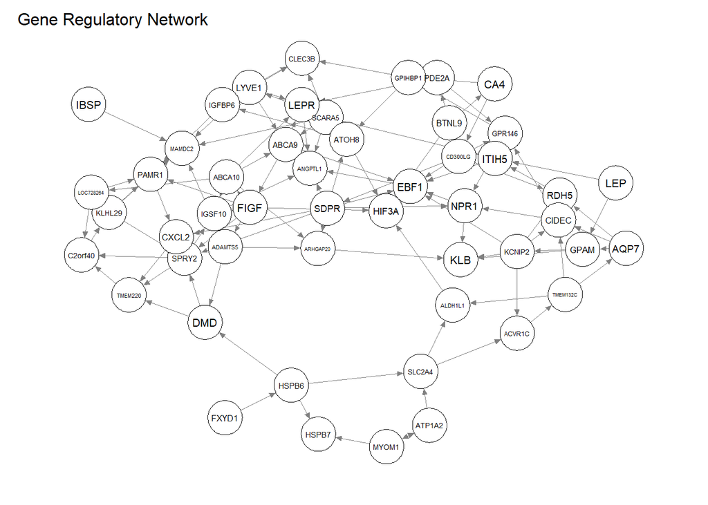

Figure 1: Gene Regulatory Network

From the visual examination, it can be inferred that the `pc_result` largely embodies the characteristics of a directed acyclic graph. However, an ambiguity in directional precedence between the variables MYCM1 and ATP1A2 introduces a loop, indicating an indeterminacy in their interrelationship.

# Find The Top 10 Other Genes That Have Strong Causal Effects On EBF1

The primary objective of causal learning is to discern the entire causal structure or causal graph from data. In contrast, causal inference aims to estimate specific causal effects, given an established causal framework. The PC algorithm primarily functions as a causal learning tool, its principal goal being the elucidation of the causal architecture within the data.

Having previously ascertained this structure via the algorithm, one can now, based on the trained pc_result, extract the top 10 genes that exert substantial causal effects on EBF1.

First convert pc_result from the causal relationship structure to an adjacency matrix.

```r
adjMatrix <- as(pc_result, "amat")
```

Then find the position of EBF1 in the data and find the genes directly connected to EBF1.

```r
ebf1_index <- which(colnames(data_no_class) == "EBF1")
ebf1_neighbors <- which(adjMatrix[ebf1_index, ] != 0)
```

The absolute value of the causal relationship between these genes and EBF1 is then calculated.

```r
causal_effects <- abs(cor(data_no_class)[ebf1_neighbors, "EBF1"])
```

The correlation coefficient matrix cor(data_no_class) is used here to estimate the causal effect between each gene and EBF1, and its absolute value is taken.

Finally, obtain the gene name corresponding to each causal effect, merge the gene name and the corresponding causal effect into a data frame, then sort the causal effects and obtain the top 10, and then print the results.

```r
# Get the gene name of the causal effect
genes_with_effects <- rownames(cor(data_no_class)[ebf1_neighbors, ])

# Merge gene names and their corresponding effects into a data frame
effects_df <- data.frame(Genes = genes_with_effects, Effects = causal_effects)

# Rank causal effects and get the top 10
top_genes <- head(effects_df[order(-effects_df$Effects),], 10)

# print result
top_genes
```

|  | Genes | Effects |
| --- | --- | --- |
| NPR1 | NPR1 | 0.9189766 |
| KCNIP2 | KCNIP2 | 0.9187560 |
| CD300LG | CD300LG | 0.9145221 |
| SDPR | SDPR | 0.8822326 |
| ITIH5 | ITIH5 | 0.8733961 |
| ABCA9 | ABCA9 | 0.8459658 |

Judging from the output results, the number of genes that “have strong causal effects on EBF1” is only 6. Although these 6 genes have high values, they do not meet the demand in terms of quantity.

Therefore, in addition to considering directly connected genes, a second degree of connectivity needs to be considered, i.e., considering genes that are two edges away (i.e., genes that are connected to the genes which are directly connected to EBF1).

The first is to calculate directly connected genes.

```r
# Extract the adjacency matrix
adj_matrix <- as(pc_result, "amat")

# Find directly connected genes to EBF1
direct_genes <- which(adj_matrix["EBF1",] == 1)

# Find the names of these genes
direct_gene_names <- colnames(adj_matrix)[direct_genes]

direct_gene_names
```

```
## [1] "CD300LG" "SDPR"    "KCNIP2"  "NPR1"    "ABCA9"   "ITIH5"
```

Judging from the output, this will produce the same results as direct processing.

The next additional calculation that needs to be done is to find second_degree_genes.

First, an empty vector is created to store other genes connected to the direct gene, that is, secondary genes.

```r
second_degree_genes <- vector()
```

Then find the secondary genes connected to the direct genes.

```r
for (gene in direct_gene_names) {
  tmp_genes <- which(adj_matrix[gene,] == 1)
  tmp_gene_names <- setdiff(colnames(adj_matrix)[tmp_genes], c(direct_gene_names, "EBF1"))
  second_degree_genes <- unique(c(second_degree_genes, tmp_gene_names))
}
```

For each gene directly linked to EBF1, the loop finds all genes linked to it and ensures that these do not include known direct genes or EBF1 itself.

Then merge direct genes and secondary genes.

```r
all_candidate_genes <- c(direct_gene_names, second_degree_genes)
```

Finally, for each candidate gene (direct or secondary gene), use the sapply function to calculate its correlation with EBF1 and take its absolute value, sort the correlations and extract the top 10 genes.

```r
correlations <- sapply(all_candidate_genes, function(gene) {
  abs(cor(data_no_class[, gene], data_no_class[, "EBF1"]))
})

ranked_genes <- names(sort(correlations, decreasing = TRUE))

# Take the top 10 genes
top_10_genes <- ranked_genes[1:10]

print(top_10_genes)
```

```
##  [1] "NPR1"    "KCNIP2"  "CD300LG" "RDH5"    "CIDEC"   "GPR146"  "BTNL9"
##  [8] "SDPR"    "GPAM"    "ITIH5"
```

Check how strongly the 10 selected genes are related to EBF1.

```r
selected_genes <- c("NPR1", "KCNIP2", "CD300LG", "RDH5", "CIDEC", "GPR146", "BTNL9", "SDPR", "GPAM", "ITIH5")

# Calculate correlation with EBF1
correlations <- sapply(selected_genes, function(gene) {
  cor(data_no_class[, gene], data_no_class[, "EBF1"])
})

# Create a data frame to display the results
correlation_df <- data.frame(Gene = selected_genes, Correlation_with_EBF1 = correlations)

correlation_df
```

|  | Gene | Correlation_with_EBF1 |
| --- | --- | --- |
| NPR1 | NPR1 | 0.9189766 |
| KCNIP2 | KCNIP2 | 0.9187560 |
| CD300LG | CD300LG | 0.9145221 |
| RDH5 | RDH5 | 0.8985167 |
| CIDEC | CIDEC | 0.8973219 |
| GPR146 | GPR146 | 0.8956943 |
| BTNL9 | BTNL9 | 0.8943198 |
| SDPR | SDPR | 0.8822326 |
| GPAM | GPAM | 0.8802229 |
| ITIH5 | ITIH5 | 0.8733961 |

This result shows the correlation between 10 selected genes and the EBF1 gene. The value of correlation ranges from -1 to 1, where 1 means a perfect positive correlation, -1 means a perfect negative correlation, and 0 means no linear correlation.

From the results, the following observations can be seen: all these genes show a high positive correlation with EBF1. The correlation between NPR1 and EBF1 is the highest, about 0.919. This means that when the expression of NPR1 increases, the expression of EBF1 is likely to increase as well, and vice versa. The correlation between ITIH5 and EBF1 is the lowest among these 10 genes, but it is still relatively high, about 0.873.

The correlation values of all genes ranged from 0.87 to 0.92, indicating a strong linear relationship between the expression patterns of these genes and EBF1.

This observation is grounded in correlation and cannot be directly inferred as causation. Nevertheless, when one takes into account the application of the PC algorithm for the construction of a causal network and the subsequent selection of genes most closely associated with EBF1 based on this network, it indeed provides a foundational basis for causal analysis.

# Find Genes In The Markov Blanket of ABCA9 From Data

IAMB (Incremental Association Markov Blanket) is a Bayesian network structure learning algorithm. This algorithm aims to discover the Markov blanket for each node, which is the set of all nodes related to a given node, conditional on all other nodes. The IAMB algorithm incrementally adds or removes candidate parent nodes to determine the optimal Markov blanket for a node.

The IAMB (Incremental Association Markov Blanket) algorithm operates as follows: Initially, it initializes an empty Markov blanket for each node in the Bayesian network. Subsequently, the algorithm iteratively refines the Markov blanket for a target node. During the incremental addition of parent nodes, it evaluates the conditional independence of the target node with other nodes, selecting a candidate parent node that exhibits the highest conditional independence and incorporating it into the Markov blanket. Following each addition, the algorithm re-evaluates conditional independence, considering the possibility of further parent node additions. Concurrently, in the incremental removal of parent nodes, the algorithm assesses the conditional independence between the target node and its existing parent nodes. If removing a parent node does not diminish the conditional independence, it is removed from the Markov blanket. This addition and removal process is repeated iteratively until no more parent nodes can be added or removed, resulting in the determination of the optimal Markov blanket for the target node. In this manner, the IAMB algorithm efficiently constructs a compact Bayesian network structure by balancing conditional independence relationships[2].

The core idea of the IAMB algorithm is to determine the parent nodes of a node by calculating conditional independence, aiming to minimize the size of the Markov blanket while preserving conditional independence relationships, thus facilitating the construction of a concise Bayesian network structure for efficient probabilistic inference.

```r
library(bnlearn)
nvar <- ncol(data_no_class)
#learn the markov blanket
MB.ABCA9=learn.mb(data_no_class, "ABCA9", method="iamb", alpha=0.01)
MB.ABCA9
```

```
##  [1] "EBF1"      "ABCA10"    "SCARA5"    "ACVR1C"    "CD300LG"   "LYVE1"
##  [7] "GPAM"      "FIGF"      "LEPR"      "LOC728264" "TMEM132C"  "HIF3A"
## [13] "LEP"       "ANGPTL1"   "PAMR1"     "CLEC3B"    "GPIHBP1"   "KLB"
## [19] "ATOH8"     "RDH5"      "NPR1"      "CIDEC"
```

The above output results are determined to be markov blankets belonging to ABCA9, ABCA9 is related or potentially interacts with these genes in biological processes.

# Discretization Of Data

Discretize the dataset into a binary format using the mean expression level of all genes as the delineation threshold.

```r
# Calculate the mean of each column
column_means <- colMeans(data_no_class)

# Calculate global mean
global_mean <- mean(column_means)

# Print the mean of each column
print(global_mean)
```

```
## [1] 304.7847
```

Then proceed to discretization.

```r
# Binarization using global mean as threshold
binary_data <- data_no_class > global_mean

# Convert TRUE to 1 and FALSE to 0
binary_data <- ifelse(binary_data, 1, 0)
```